# Exercicio1

**1 - Considere uma matriz esparça (document-term matrix), em que tfij é a frequência da i-ésima palavra (termo) no j-ésimo documento e m é o número de documentos. Considere a transformação da variável que é definida por ... onde dfi é o número de documentos em que o i-ésimo termo aparece e é conhecido como a frequência do documento do termo. Essa transformação é conhecida como transformação inversa da frequência do documento**

**a) Qual é o efeito dessa transformação se um termo ocorrer em um documento? E em todos os documentos?**

Se o termo ocorre em apenas um documento sua frequencia será multiplicada pelo log do numero de documentos, desta forma este termo será destacado por ser mais raro. Caso contrario se o termo ocorre em todos os documentos então dfi = m, desta forma sua frequência será multiplicada pelo log de 1 o que anula sua frequência.

**b) Qual pode ser o propósito dessa transformação?**

Esta transformação destaca termos que são mais 'raros' que devem ser considerados mais relevantes quando uma busca for realizada.

**2 - Para os seguintes vetores, x e y, calcule as medidas de semelhança ou distância indicadas.**

```python
import math

def med(x):
    soma = 0
    for i in range(0, len(x)):
        soma += x[i]
    med = soma/len(x)
    return(med)

def cov(x, y):
    medX = med(x)
    medY = med(y)
    soma = 0
    for i in range(0, len(x)):
        soma += ((x[i] - medX) * (y[i] - medY))
    cov = soma/(len(x)-1)
    return(cov)

def sdev(x):
    medX = med(x)
    soma = 0
    for i in range(0, len(x)):
        soma += ((x[i] - medX) * (x[i] - medX))
    sdev = math.sqrt(soma/(len(x)-1))
    return(sdev)

def cos(x, y):
    prod = 0
    magX = 0
    magY = 0
    for i in range (0, len(x)):
        prod += x[i]*y[i]
        magX += x[i]*x[i]
        magY += y[i]*y[i]
    magX = math.sqrt(magX)
    magY = math.sqrt(magY)
    cos = prod/(magX*magY)
    return(cos)

def corr(x, y):
    covXY = cov(x, y)
    sdevX = sdev(x)
    sdevY = sdev(y)
    if(sdevX == 0 or sdevY == 0):
        return("Undefined")
    corr = covXY/(sdevX*sdevY)
    return(corr)

def euc(x, y):
    soma = 0
    for i in range (0, len(x)):
        soma += (x[i] - y[i])*((x[i] - y[i]))
    euc = math.sqrt(soma)
    return(euc)

def jac(x, y):
    f01 = 0
    f10 = 0
    f11 = 0
    for i in range (0, len(x)):
        if(x[i] == 0 and y[i] == 1):
            f01 += 1
        elif(x[i] == 1 and y[i] == 0):
            f10 += 1
        elif(x[i] == 1 and y[i] == 1):
            f11 += 1
    jac = f11/(f01+f10+f11)
    return(jac)
```

**a) x = (1, 1, 1, 1), y = (2, 2, 2, 2) cosine, correlação, Euclidean**

```python
x = [1, 1, 1, 1]
y = [2, 2, 2, 2]

print(cos(x, y))
print(corr(x, y))
print(euc(x, y))
```

```
1.0
Undefined
2.0
```

**b) x = (0, 1, 0, 1), y = (1, 0, 1, 0) cosine, correlação, Euclidean, Jaccard**

```python
x = [0, 1, 0, 1]
y = [1, 0, 1, 0]

print(cos(x, y))
print(corr(x, y))
print(euc(x, y))
print(jac(x, y))
```

```
0.0
-1.0
2.0
0.0
```

**c) x = (0, −1, 0, 1), y = (1, 0, −1, 0) cosine, correlação, Euclidean**

```python
x = [0, -1, 0, 1]
y = [1, 0, -1, 0]

print(cos(x, y))
print(corr(x, y))
print(euc(x, y))
```

```
0.0
0.0
2.0
```

**d) x = (1, 1, 0, 1, 0, 1), y = (1, 1, 1, 0, 0, 1) cosine, correlação, Jaccard**

```python
x = [1, 1, 0, 1, 0, 1]
y = [1, 1, 1, 0, 0, 1]

print(cos(x, y))
print(corr(x, y))
print(jac(x, y))
```

```
0.75
0.25
0.6
```

**e) x = (2, −1, 0, 2, 0, −3), y = (−1, 1, −1, 0, 0, −1) cosine, correlação**

```python
x = [2, -1, 0, 2, 0, -3]
y = [-1, 1, -1, 0, 0, -1]

print(cos(x, y))
print(corr(x, y))
```

```
0.0
-5.733167046599012e-17
```

**3 - Aqui, exploramos ainda mais as medidas de cosseno e correlação.**

**a) Qual é a faixa de valores possíveis para a medida do cosseno?**

Os possiveis valores para o cosseno existem no intervalo de 0 a 1.

**b) Se dois objetos têm uma medida de cosseno de 1, eles são idênticos? Explique.**

Não necessariamente. Ter uma medidada de cosseno 1 apenas indica que os objetos tem a mesma inclinação, podemos verificar na latra a do exercicio anterior que dois objetos diferentes tem uma medida de cosseno 1.

**4 - Discutir as diferenças entre a redução da dimensionalidade com base em agregação e da redução da dimensão com base em técnicas como PCA.**

Reduções com base em agragação combinam 2 ou mais atribuitos em um unico atributo. Agregações não tem como abjetivo apenas a redução de dimenções mas também mudanças de escala bem como formatações mais 'estaveis' dos dados. Reduções com base em técnicas como PCA tem como objetivo apenas a redução de dimenções. O PCA, por exemplo, apenas busca achar uma projeção que capture a maior variação nos dados, não sem importando com escala ou formatação dos dados.

**Parte 2 - Exercícios referentes a obtenção de dados**

**5- Adaptar o coletor de nome de produto da Magazine Luíza para capturar também o preço do produto.**

```python
import requests
from bs4 import BeautifulSoup


##pagina porcao Fourquare

url="https://www.magazineluiza.com.br/cafeteira-francesa-prensa-francesa-600-ml/p/jf3e835h66/ud/prsf/"

##retorna o conteudo da pagina
req = requests.get(url)

##transforma o conteudo da pagina em um objeto BeautifulSoup
soup = BeautifulSoup(req.content,'html.parser')

nomeBruto = soup.find("h1",{"class":"header-product__title"})

print(nomeBruto)

print(nomeBruto.text)

precoBruto = soup.find("div",{"class":"price-template"})

print(precoBruto)

preco = soup.find("div", {"class":"price-template"})

print(preco.text)
```

```
<h1 class="header-product__title">Cafeteira Francesa - Prensa Francesa 600 Ml</h1>
Cafeteira Francesa - Prensa Francesa 600 Ml
<div class="price-template"> <div class="price-template__from">de R$ 49,49</div> <div class="price-template">por R$ 37,49</div> <div class="price-template__cash--margin"> <div class="price-template-price-block"> <span class="price-template__bold">R$</span> <span class="price-template__text">34,87</s…
 de R$ 49,49 por R$ 37,49   R$ 34,87 (7% de desconto)
```

**Parte 3 - Exercícios referentes à análise de dados**

**6 - Obtenha o dataset do desafio: https://www.kaggle.com/t/43c48adfa2974254b1ab5f4d155033f0. Após se familiarizar com os dados e entender a sua organização, quais técnicas de visualização e exploração de dados poderiam ser aplicáveis e úteis para entender melhor esses dados? (veja o material disponibilizado e o capítulo 3 do livro base). Justifique as suas escolhas.**

Após a analise dos dados acredito que as técnicas de histograma, CDF e heatmaps seriam bem aplicadas a nosso dataset visto que podemos analizar a distribuição de avaliações por estabelecimento, bem como a distribuição de estabelecimentos pela cidade.

**7 - Com base na resposta da questão 6, realize algumas das opções levantadas (pelo menos três tipos diferentes). Apresente os principais insights obtidos com as análises.**

```python
#Análise e manipulação de dados
import pandas as pd

#Visualização de dados
import matplotlib.pyplot as plt
import seaborn as sns

#Recursos estatísticos
from scipy import stats

#Vizualização geoespacial
import folium
from folium.plugins import HeatMap

# Caso esteja acessando na sua máquina
train = pd.read_csv('X_trainCharlotte.csv')
```

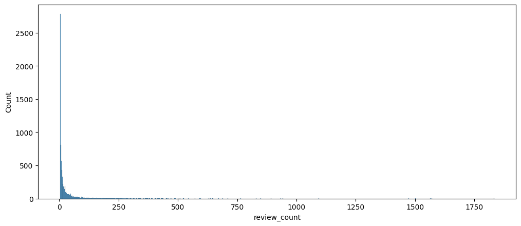

```python
fig = plt.figure(figsize=(12,5), dpi= 100, facecolor='w', edgecolor='k')
fig = sns.histplot(train['review_count'])
```

A partir do histograma podemos perceber que a grande maioria dos estabelicimentos tem poucas analises. Isto pode indicar que os estabelecimentos mais populares apresentam mais analises.

[figure not shown]

```python
ax = sns.ecdfplot(data = train, x='review_count', log_scale=True )
ax.set(ylabel=r'$P(X \leq x)$')
plt.show()
```

Análogo ao histograma porém com uma visualização melhor. Podemos perceber que a probabilidade de um estabalecimento ter recebido muitas análises diminue de maneira muito veloz com o aumento do número de análises.

```python
maxlat = train['latitude'].max()
minlon = train['longitude'].min()
mapaCharlotte = folium.Map(location=[maxlat, minlon])

pontos  = [[ row['latitude'],row['longitude']] for index, row in train.iterrows()]

HeatMap(pontos).add_to(mapaCharlotte)
mapaCharlotte
```

[interactive chart not shown]

Com o heatmap é possivel visualizar quais as regiões da cidade de Charlotte há a maior concentração de estabelecimentos. Desta forma também podemos supor que os estabelecimentos mais poximos destas áreas são mais populares.

**8 - Algum dos resultados encontrados na questão 7 pode ser útil na resolução do problema proposto em https://www.kaggle.com/t/43c48adfa2974254b1ab5f4d155033f0? Discutir todos que forem identificados.**

Acredito que principalmente o heatmap e o histograma são os mais úteis em nossa análise. Poderiamos criar uma distribuição dos estabelecimentos com mais analises em função de sua localização geografia e assim teriamos uma previsão ainda melhor dos estabelicimentos mais populares.